# Exploratory Data Analysis Project

Andrew Witherspoon

10/6/2018

Load the two files, which are already R objects, downloaded to our working directory’s subfolder, “data”:

```r
NEI <- readRDS("./data/summarySCC_PM25.rds")
SCC <- readRDS("./data/Source_Classification_Code.rds")
```

First we will explore if the total emissions from PM2.5 have decreased in the United States from 1999 - 2008.

First we will look at the number of observations taken each year

```r
 table(as.factor(NEI$year))
```

```
##
##    1999    2002    2005    2008
## 1108469 1698677 1713850 1976655
```

The number of observations has increased each year, so the total measured PM2.5 may be inflated in later years, but we will answer the questions as asked.

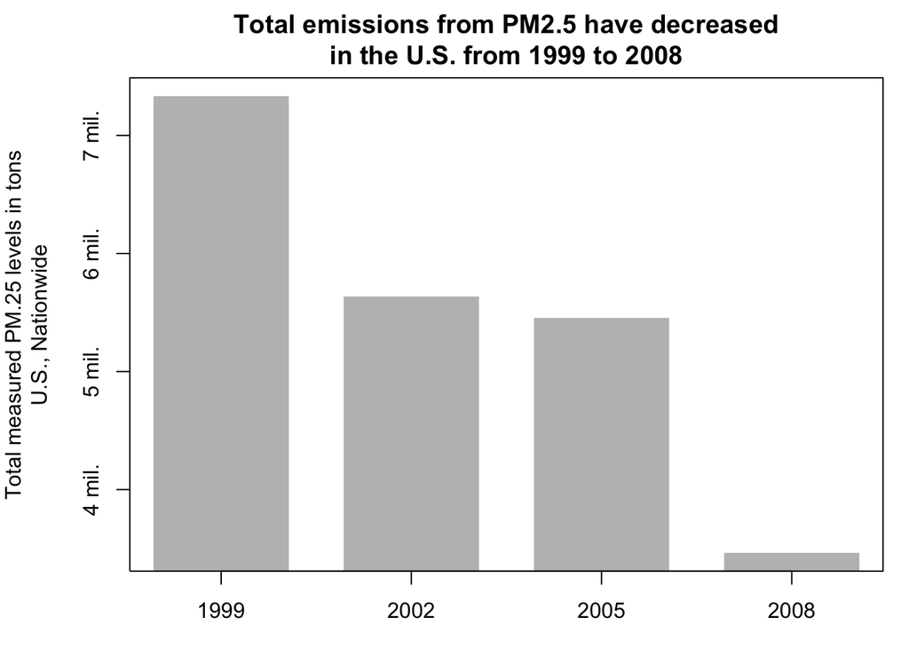

```r
totallevels <- with(NEI, tapply(Emissions, as.factor(year), sum))
par(mar = c(3,5,3,1))
plot(names(totallevels), totallevels,
     type = "h", lwd = 100, lend = 1, xaxt = 'n', yaxt = 'n',
     ylab = "Total measured PM.25 levels in tons\nU.S., Nationwide", xlab = "",
     pch = 19, cex = 2, xlim = c(1998, 2009), col = "grey")
axis(side = 1, at = names(totallevels))
axis(side = 2, at = c(4000000, 5000000, 6000000, 7000000),
     labels = (c("4 mil.", "5 mil.", "6 mil.", "7 mil.")))
title(main = "Total emissions from PM2.5 have decreased\nin the U.S. from 1999 to 2008")
```

Have total emissions from PM2.5 decreased in Baltimore City Maryland (fips 24510) from 1999 to 2008?

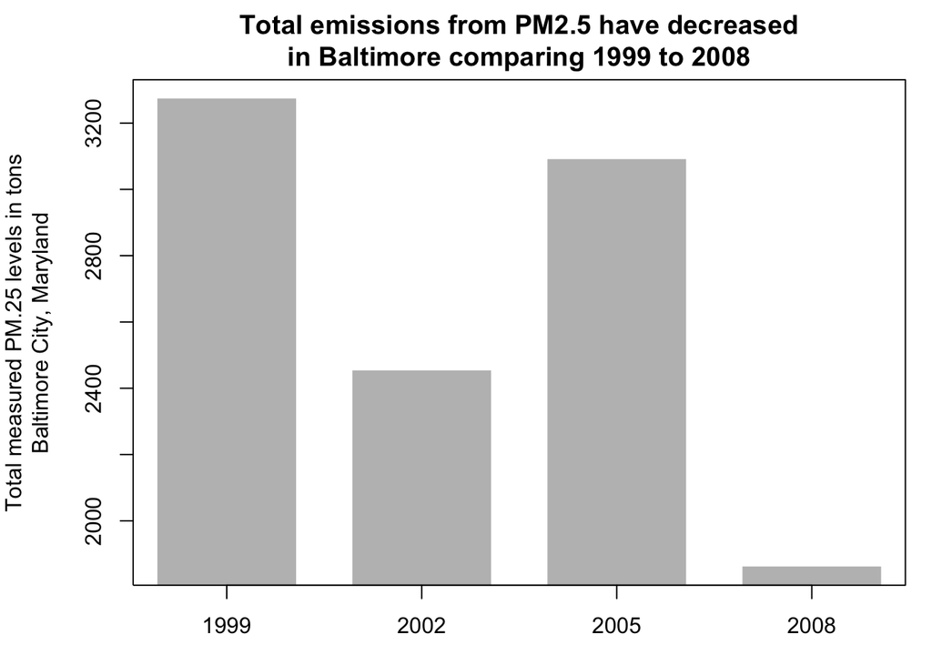

```r
NEIbal <- NEI[NEI$fips == "24510",]
Ballevels <- with(NEIbal, tapply(Emissions, as.factor(year), sum))
par(mar = c(3,5,3,1))
plot(names(Ballevels), Ballevels,
     type = "h", lwd = 100, lend = 1, xaxt = 'n',
     ylab = "Total measured PM.25 levels in tons\nBaltimore City, Maryland", xlab = "",
     pch = 19, cex = 2, xlim = c(1998, 2009), col = "grey")
axis(side = 1, at = names(Ballevels))
title(main = "Total emissions from PM2.5 have decreased\nin Baltimore comparing 1999 to 2008")
```

Of the four types of sources inicated by the **type** (point, nonpoint, onroad, nonroad) variable, which of these four sources have seen decreases in emissions from 1999 - 2008 for **Baltimore City**? Which have seen increases?

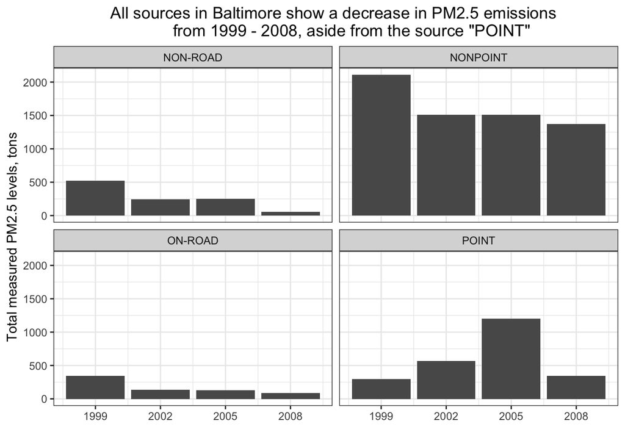

```r
NEIbal <- NEI[NEI$fips == "24510",]

library(ggplot2)

p1 <- ggplot(NEIbal, aes(year)) +
  geom_bar(aes(weight = Emissions)) +
  facet_wrap(~type)+
  theme_bw() +
  xlab("") +
  ylab("Total measured PM2.5 levels, tons") +
  scale_x_continuous(breaks = c(1999, 2002, 2005, 2008),
                   labels = c("1999", "2002", "2005", "2008")) +
  labs(title = "All sources in Baltimore show a decrease in PM2.5 emissions
       from 1999 - 2008, aside from the source \"POINT\"") +
  theme(plot.title = element_text(hjust = 0.5))
p1
```

Across the United States, how have emissions from the coal combustion-related sources changed from 1999 - 2008?

```r
coalSCC <- SCC[grepl("coal", SCC$EI.Sector, ignore.case = TRUE),]
#subset just those observations that contain the word "coal" in the EI.Sector field

coalNEI <- NEI[NEI$SCC %in% coalSCC$SCC,]
#subset our main dataframe to just those observations that have a SCC that is also in the coalSSC dataframe we just created
```

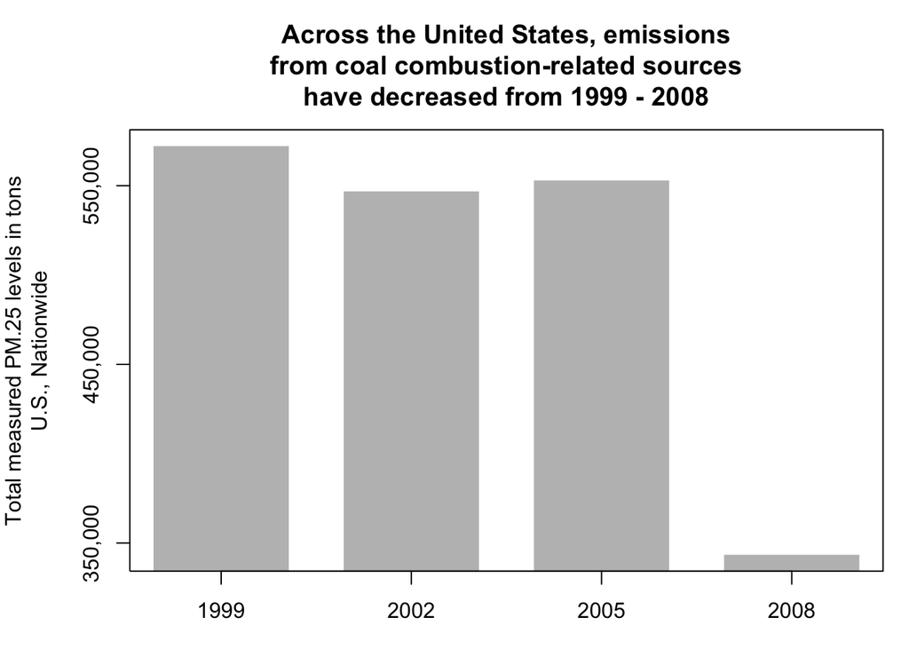

```r
totallevels <- with(coalNEI, tapply(Emissions, as.factor(year), sum))
par(mar = c(3,5,5,1))
plot(names(totallevels), totallevels,
     type = "h", lwd = 100, lend = 1, xaxt = 'n', yaxt = 'n',
     ylab = "Total measured PM.25 levels in tons\nU.S., Nationwide", xlab = "",
     pch = 19, cex = 2, xlim = c(1998, 2009), col = "grey")
axis(side = 1, at = names(totallevels))
axis(side = 2, at = c(350000, 450000, 550000),
     labels = (c("350,000", "450,000", "550,000")))
title(main = "Across the United States, emissions\nfrom coal combustion-related sources\nhave decreased from 1999 - 2008")
```

How have emissions from motor vehicles sources changed from 1999-2008 in Baltimore City?

```r
vehicleSCC <- SCC[grepl("vehicle", SCC$EI.Sector, ignore.case = TRUE),]
#subset just those observations that contain the word "vehicle" in the EI.Sector field

vehicleNEI <- NEI[NEI$SCC %in% vehicleSCC$SCC,]
#subset our main dataframe to just those observations that have a SCC that is also in the vehicleSSC dataframe we just created

vehicleNEIbal <- vehicleNEI[vehicleNEI$fips == "24510",]
```

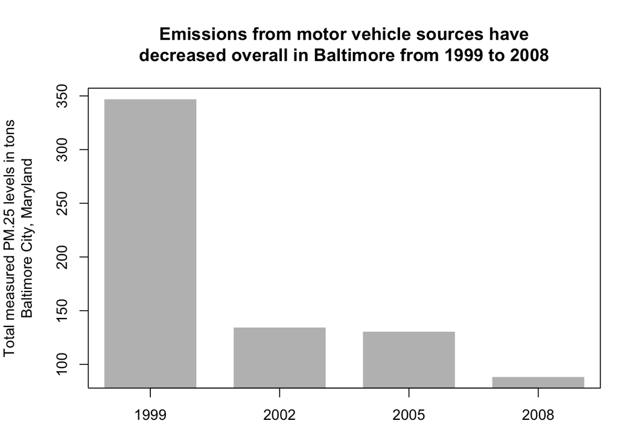

```r
Ballevels <- with(vehicleNEIbal, tapply(Emissions, as.factor(year), sum))
par(mar = c(3,5,5,1))
plot(names(Ballevels), Ballevels,
     type = "h", lwd = 100, lend = 1, xaxt = 'n',
     ylab = "Total measured PM.25 levels in tons\nBaltimore City, Maryland", xlab = "",
     pch = 19, cex = 2, xlim = c(1998, 2009), col = "grey")
axis(side = 1, at = names(Ballevels))
title(main = "Emissions from motor vehicle sources have\ndecreased overall in Baltimore from 1999 to 2008")
```

Compare emissions from motor vehicle sources in Baltimore City with emissions from motor vehicles sources in Los Angeles County, California. Which city has seen greater changes over time in motor vehicle emissions?

```r
vehicleSCC <- SCC[grepl("vehicle", SCC$EI.Sector, ignore.case = TRUE),]
#subset just those observations that contain the word "vehicle" in the EI.Sector field

vehicleNEI <- NEI[NEI$SCC %in% vehicleSCC$SCC,]
#subset our main dataframe to just those observations that have a SCC that is also in the vehicleSSC dataframe we just created

vehicleNEIbalLA <- vehicleNEI[vehicleNEI$fips == "24510" | vehicleNEI$fips == "06037",]
vehicleNEIbalLA$fips[vehicleNEIbalLA$fips == "24510"] <- "Baltimore"
vehicleNEIbalLA$fips[vehicleNEIbalLA$fips == "06037"] <- "Los Angeles"
```

```r
totallevels <- with(vehicleNEIbalLA, tapply(Emissions, list(year, fips), sum))
totallevels
```

```
##      Baltimore Los Angeles
## 1999 346.82000    3931.120
## 2002 134.30882    4274.030
## 2005 130.43038    4601.415
## 2008  88.27546    4101.321
```

```r
library(reshape2)
totallevels <- as.data.frame(totallevels)
totallevels$year <- rownames(totallevels)
totallevels
```

```
##      Baltimore Los Angeles year
## 1999 346.82000    3931.120 1999
## 2002 134.30882    4274.030 2002
## 2005 130.43038    4601.415 2005
## 2008  88.27546    4101.321 2008
```

```r
totallevels <- melt(totallevels,
                    id.vars = c(3),
                    measure.vars = c(1,2)
                    )
names(totallevels) <- c("year", "City", "Emissions")
totallevels$year <- as.numeric(totallevels$year)
totallevels
```

```
##   year        City  Emissions
## 1 1999   Baltimore  346.82000
## 2 2002   Baltimore  134.30882
## 3 2005   Baltimore  130.43038
## 4 2008   Baltimore   88.27546
## 5 1999 Los Angeles 3931.12000
## 6 2002 Los Angeles 4274.03020
## 7 2005 Los Angeles 4601.41493
## 8 2008 Los Angeles 4101.32100
```

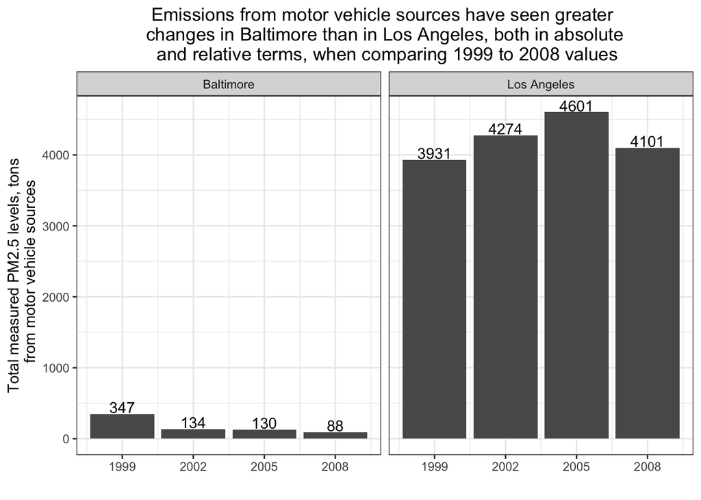

```r
library(ggplot2)
p2 <- ggplot(totallevels, aes(year)) +
  geom_bar(aes(weight = Emissions)) +
  facet_grid(~City) +
  geom_text(aes(y=Emissions, label = round(Emissions)), vjust = -.11) +
  theme_bw() +
  xlab("") +
  ylab("Total measured PM2.5 levels, tons
  from motor vehicle sources") +
  scale_x_continuous(breaks = c(1999, 2002, 2005, 2008),
                   labels = c("1999", "2002", "2005", "2008")) +
  labs(title =
 "Emissions from motor vehicle sources have seen greater
 changes in Baltimore than in Los Angeles, both in absolute
 and relative terms, when comparing 1999 to 2008 values") +
  theme(plot.title = element_text(hjust = .5))
p2
```